# Homework Data Viz

Arnuparb

2023-03-23

# Hello world

This is markdown language. Today we learn a few topics in R.

- databases
- working with data
- ggplot2
- rmarkdown

## Homework

Explore dataframe diamonds and create 5 Visulization.

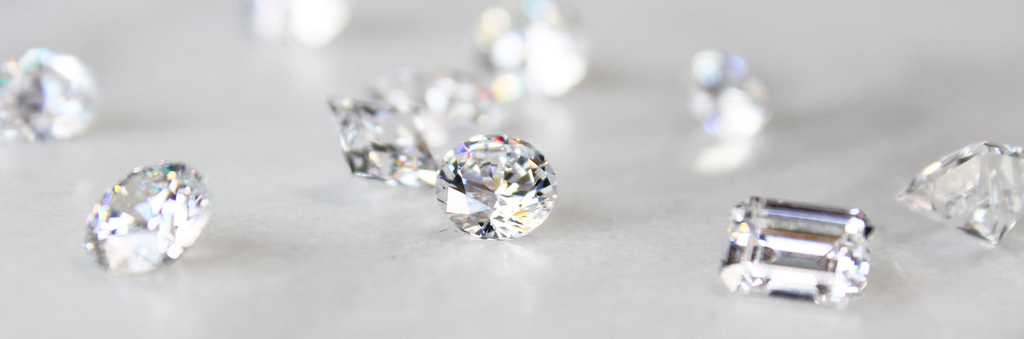

shine light like a diamond!

## Chart 1 - relationship between carat and price

```r
library(tidyverse)
head(diamonds)
```

```
## # A tibble: 6 × 10
##   carat cut       color clarity depth table price     x     y     z
##   <dbl> <ord>     <ord> <ord>   <dbl> <dbl> <int> <dbl> <dbl> <dbl>
## 1  0.23 Ideal     E     SI2      61.5    55   326  3.95  3.98  2.43
## 2  0.21 Premium   E     SI1      59.8    61   326  3.89  3.84  2.31
## 3  0.23 Good      E     VS1      56.9    65   327  4.05  4.07  2.31
## 4  0.29 Premium   I     VS2      62.4    58   334  4.2   4.23  2.63
## 5  0.31 Good      J     SI2      63.3    58   335  4.34  4.35  2.75
## 6  0.24 Very Good J     VVS2     62.8    57   336  3.94  3.96  2.48
```

## Create my first chart!

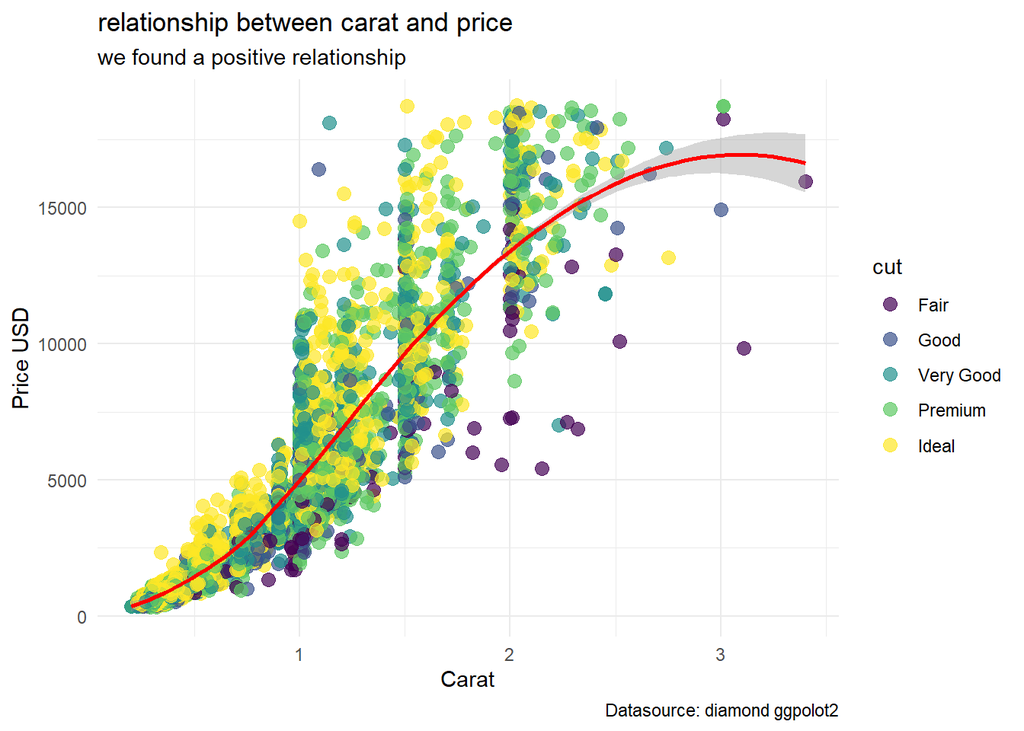

```r
set.seed(42)
ggplot(diamonds %>% sample_n(5000),
       aes(carat,price, col=cut)) +
  geom_point(alpha=0.7, size=3) +
  geom_smooth(method = "loess", col= "red") +
  theme_minimal() +
  labs(title = "relationship between carat and price",
       x = "Carat",
       y = "Price USD",
       subtitle = "we found a positive relationship",
       caption = "Datasource: diamond ggpolot2"
  )
```

According to the correlation between carat weight and price, a higher carat weight has a greater impact on the price. Furthermore, it was discovered that the cut variety is most common between 0 and 2 carats, with the larger carats being found less frequently the higher the cut.

## Chart 2 - Relationship between carat and depth

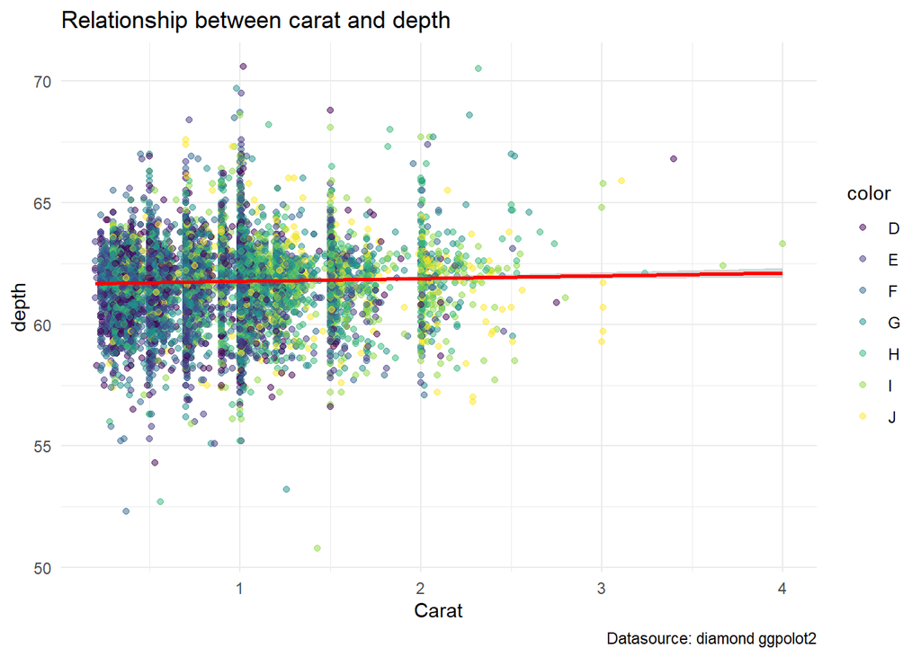

```r
set.seed(42)
ggplot(diamonds %>% sample_n(10000),
       aes(carat,depth, col=color))+
  geom_point(alpha=0.5) +
  geom_smooth(method = "lm", col="red") +
  theme_minimal() +
  labs(title = "Relationship between carat and depth",
       x = "Carat",
       y = "depth",
       caption = "Datasource: diamond ggpolot2"
  )
```

Carat and depth comparison chart: generally low carat clustering, depth between 60 and 65, and in the colour area, clustering of less than 2 carats.

## Chart 3 - Relationship between Clarity and price

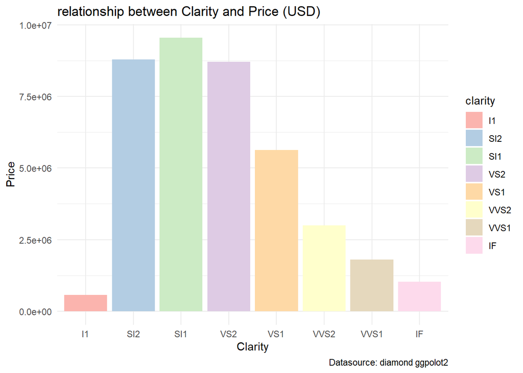

```r
set.seed(42)
ggplot(diamonds %>% sample_n(10000),
       aes(clarity, price, fill=clarity)) +
  geom_col() +
  theme_minimal() +
  scale_fill_brewer(type = "qual", palette = 4)+
  labs(title = "relationship between Clarity and Price (USD)",
       x = "Clarity",
       y = "Price",
       caption = "Datasource: diamond ggpolot2"
  )
```

## Chart 4 - Relationship between cut and count affect by clarity

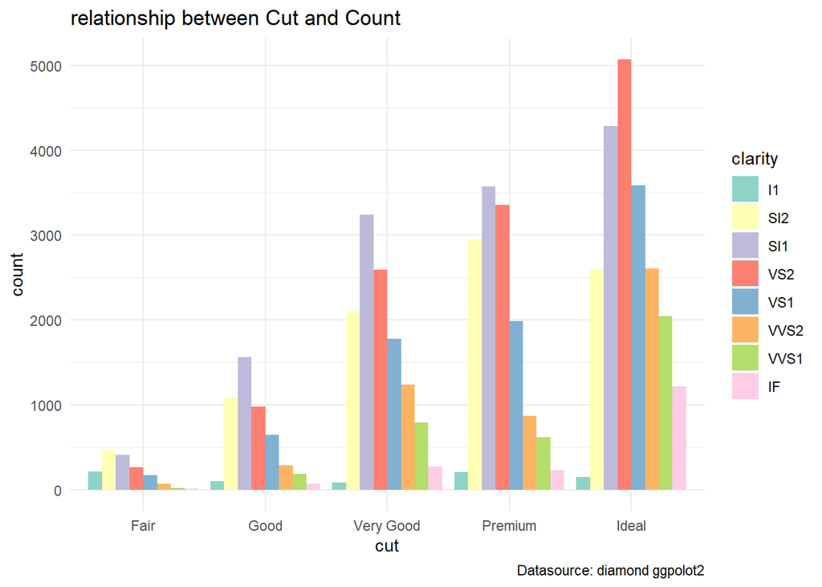

```r
set.seed(42)
ggplot(diamonds, aes(cut, fill=clarity)) +
  geom_bar(position = "dodge") +
  theme_minimal()+
  labs(title = "relationship between Cut and Count",
       x = "cut",
       y = "count",
       caption = "Datasource: diamond ggpolot2"
  ) +
  scale_fill_brewer(type = "qual", palette = 8)
```

## Chart 5 - Relationship between carat and table affect by color

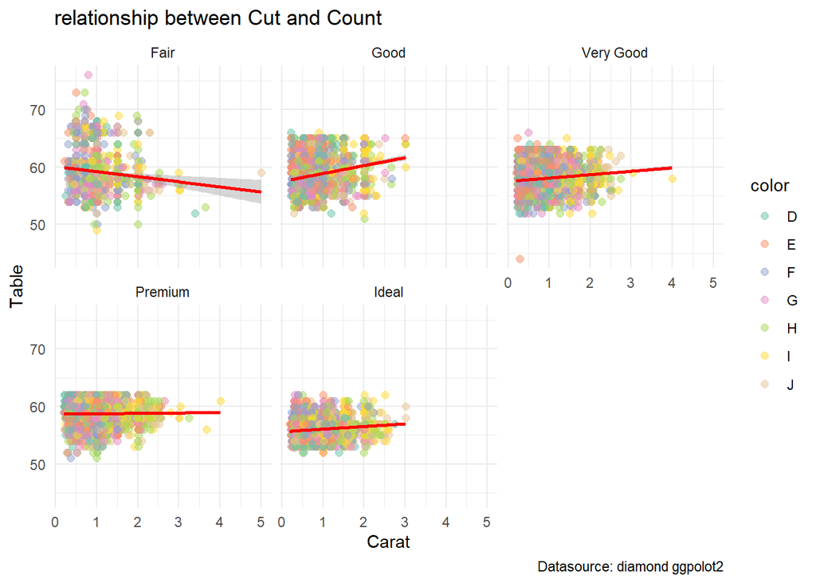

```r
set.seed(42)
ggplot(diamonds %>% sample_n(25000),
       aes(carat,table, col=color)) +
  geom_point(alpha=0.5, size=2) +
  geom_smooth(method="lm", col="red") +
  theme_minimal() +
  facet_wrap(~ cut, ncol=3)+
  labs(title = "relationship between Cut and Count",
       x = "Carat",
       y = "Table",
       caption = "Datasource: diamond ggpolot2"
  ) +
   scale_color_brewer(type = "qual", palette = 7)
```

The comparison graph between carat and table revealed that they are clustered at carat not exceeding 2 and finding table between 50 and 70, whereas the higher cut type will find table not exceeding 65.